# COMP5319 - Assignment 1

## Instructions for running the code

To run the code, please run each individual cell sequentially. To do this, you can manually run each cell, or you can choose to run all cells sequentially automatically by pressing CMD+F9 (MAC) or CTRL+F9 (PC).

The second code cell in the sheet downloads the relevant data from Google Drive. When this cell is run, you will need to give Google Colab permission to access Google Drive. After this, all cells will run without any further input needed from your side.

Most of the code under the section "Experiments" has been commented out. This section contains the code for the hyperparameter analyses and ablation studies. Running all of these cells takes a long time, so we have chosen to comment them out in our submission. If you would like to run the code yourself, please uncomment the code in these cells.

## Importing relevant libraries

```python
### IMPORT THE LIBRARIES/FUNCTIONS THAT ARE USED IN THE PROJECT
# Libraries for downloading data
import os
from glob import glob
from google.colab import drive
# Libraries for mathematical and vector operations
import math
from scipy.special import erf
from scipy.stats import norm
import numpy as np
# Libraries for visualisation
import matplotlib.pyplot as plt
# Measuring time
import time
# Evaluation metrics
from sklearn.metrics import accuracy_score, f1_score, classification_report
```

## Data Loading

```python
### THIS CELL REQUIRES ACTION FROM YOUR SIDE;
### PLEASE ALLOW ACCESS TO YOUR GOOGLE DRIVE CREDENTIALS
# Code to download file into Colaboratory:
!pip install -U -q PyDrive
from pydrive.auth import GoogleAuth
from pydrive.drive import GoogleDrive
from google.colab import auth
from oauth2client.client import GoogleCredentials
# Authenticate and create the PyDrive client.
auth.authenticate_user()
gauth = GoogleAuth()
gauth.credentials = GoogleCredentials.get_application_default()
drive = GoogleDrive(gauth)
# Train data
id = '1fEIw-jCFphpowvJzKPWE9jlpVITRqqic'
downloaded = drive.CreateFile({'id':id})
downloaded.GetContentFile('train_data.npy')
train_data = np.load('train_data.npy')
# Train labels
id = '1uMSjm0l_qN1jeKNnFyq9bKTwkfkGqxU6'
downloaded = drive.CreateFile({'id':id})
downloaded.GetContentFile('train_label.npy')
train_label = np.load('train_label.npy')
# Test data
id = '15WxtYo29-ljUIGxTA52mCc93twJsxnAd'
downloaded = drive.CreateFile({'id':id})
downloaded.GetContentFile('test_data.npy')
test_data = np.load('test_data.npy')
# Test labels
id = '1WIyEWCZoxvIZlEyCM_4sJFFbb-3n4N2I'
downloaded = drive.CreateFile({'id':id})
downloaded.GetContentFile('test_label.npy')
test_label = np.load('test_label.npy')
```

## Exploratory data analysis

```python
# Dimensions of training and testing data
print("Training dataset dimensions:",train_data.shape)
print("Training output dataset dimensions:",train_label.shape)
print("Testing dataset dimensions:",test_data.shape)
print("Testing output dataset dimensions:",test_label.shape)
```

```
Training dataset dimensions: (50000, 128)
Training output dataset dimensions: (50000, 1)
Testing dataset dimensions: (10000, 128)
Testing output dataset dimensions: (10000, 1)
```

```python
# Let's see if the training set is balanced
d={}
for i in [int(i) for i in train_label]:
  d[i] = d.get(i,0)+1
d
```

```
{6: 5000,
 9: 5000,
 4: 5000,
 1: 5000,
 2: 5000,
 7: 5000,
 8: 5000,
 3: 5000,
 5: 5000,
 0: 5000}
```

Yes it is, every target label has exactly 5000 examples.

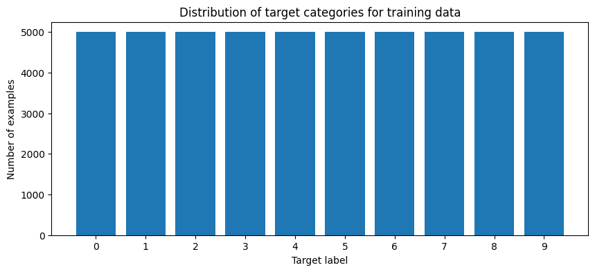

```python
# Visualise the balanced distribution of traing set lavels
x = [i for i in d.keys()]
y = [i for i in d.values()]
plt.figure(figsize=(10,4))
plt.bar(x, y)
plt.xticks([x for x in range(10)])
plt.title("Distribution of target categories for training data")
plt.xlabel("Target label")
plt.ylabel("Number of examples")
plt.show()
```

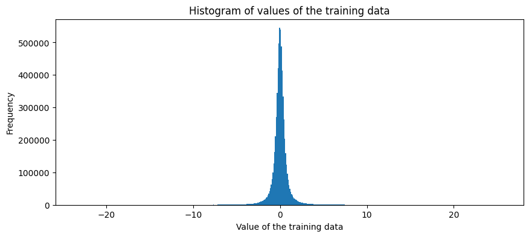

```python
# How are the training values distributed?
y = np.concatenate([np.array(i) for i in train_data])
plt.figure(figsize=(10,4))
plt.hist(y, bins=500)
plt.title("Histogram of values of the training data")
plt.xlabel("Value of the training data")
plt.ylabel("Frequency")
plt.show()
```

```python
# What is the largest and smallest value in the training dataset?
print("Largest number in the training dataset:", max(y))
print("Smallest number in the training dataset:", min(y))
```

```
Largest number in the training dataset: 25.581360537720347
Smallest number in the training dataset: -23.41520966868848
```

```python
# What example and what dimension has the largest value?
print("Example number of max value:", np.argmax(y) / 128)
print("Position of max value in that example:", np.argmax(y) % 128)
train_data[int(np.argmax(y) / 128)][int(np.argmax(y) % 128)]
```

```
Example number of max value: 9881.0
Position of max value in that example: 0
```

```
25.581360537720347
```

```python
# What example and what dimension has the smallest value?
print("Example number of min value:", np.argmin(y) / 128)
print("Position of min value in that example:", np.argmin(y) % 128)
train_data[int(np.argmin(y) / 128)][int(np.argmin(y) % 128)]
```

```
Example number of min value: 44590.0
Position of min value in that example: 0
```

```
-23.41520966868848
```

Most are quite small, but there are some outliers. Both the largest and the smallest value are located in feature dimension 0.

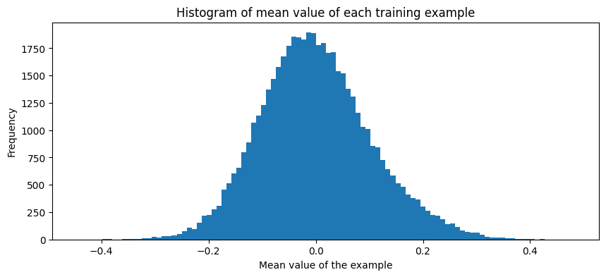

```python
# How are the mean values of the examples distributed?
means = [np.mean(i) for i in train_data] # np.mean(train_data, axis=1)
plt.figure(figsize=(10,4))
plt.hist(means, bins=100)
plt.title("Histogram of mean value of each training example")
plt.xlabel("Mean value of the example")
plt.ylabel("Frequency")
plt.show()
```

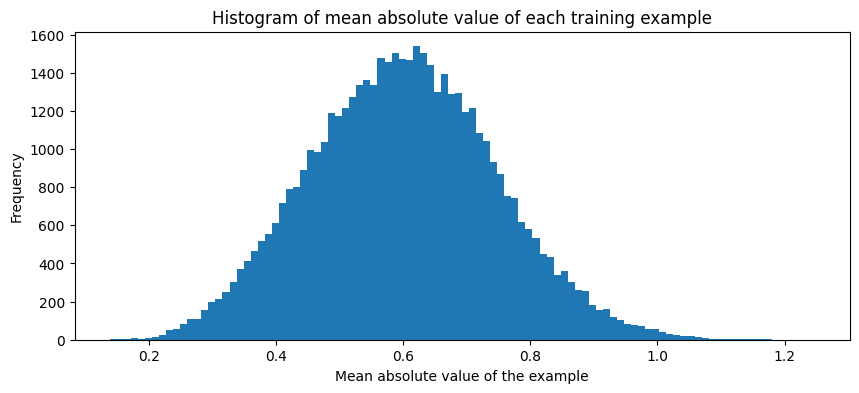

```python
# How are the mean absolute values of the examples distributed?
means = [np.mean(np.absolute(i)) for i in train_data] # np.mean(np.absolute(train_data), axis=1)
plt.figure(figsize=(10,4))
plt.hist(means, bins=100)
plt.title("Histogram of mean absolute value of each training example")
plt.xlabel("Mean absolute value of the example")
plt.ylabel("Frequency")
plt.show()
```

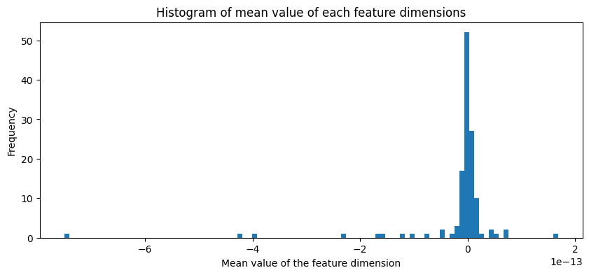

```python
# How are the mean values of the dimensions distributed?
means = np.mean(train_data, axis=0)
plt.figure(figsize=(10,4))
plt.hist(means, bins=100)
plt.title("Histogram of mean value of each feature dimensions")
plt.xlabel("Mean value of the feature dimension")
plt.ylabel("Frequency")
plt.show()
```

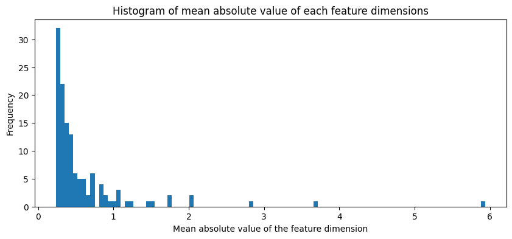

```python
# How are the mean absolute values of the dimensions distributed?
means = np.mean(np.absolute(train_data), axis=0)
plt.figure(figsize=(10,4))
plt.hist(means, bins=100)
plt.title("Histogram of mean absolute value of each feature dimensions")
plt.xlabel("Mean absolute value of the feature dimension")
plt.ylabel("Frequency")
plt.show()
```

```python
# What dimension has the outlying value?
print("Index of outlier dimension:",np.argmax(means))
```

```
Index of outlier dimension: 0
```

This confirms that feature dimension 0 contains the largest data points in terms of absolute value!

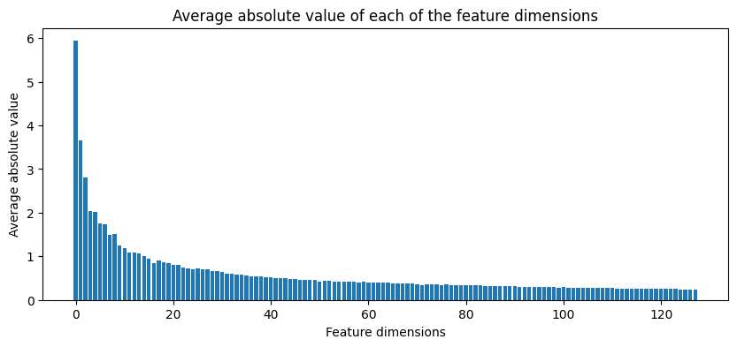

```python
# Training set balance
x = [i for i in range(len(means))]
y = means
plt.figure(figsize=(10,4))
plt.bar(x, y)
plt.title("Average absolute value of each of the feature dimensions")
plt.xlabel("Feature dimensions")
plt.ylabel("Average absolute value")
plt.show()
```

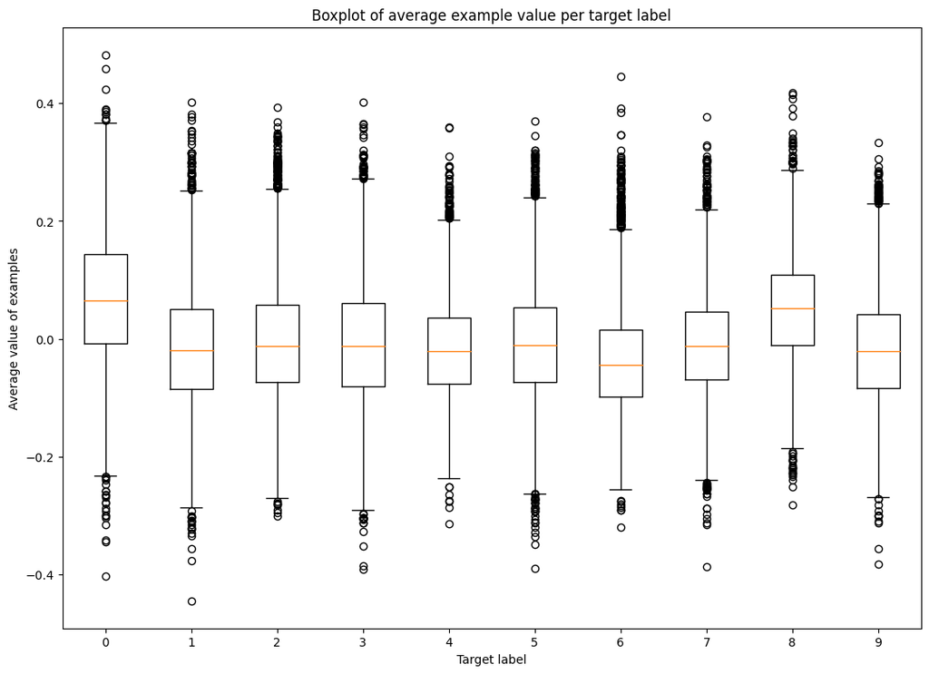

```python
# Now let's plot the mean example value per target category
data = []
for label in range(10):
  data.append([np.mean(val) for i, val in enumerate(train_data) if train_label[i]==label])

fig = plt.figure(figsize =(10, 7))
ax = fig.add_axes([0, 0, 1, 1])
bp = ax.boxplot(data)
ax.set_xticklabels([x for x in range(10)])
plt.title("Boxplot of average example value per target label")
plt.xlabel("Target label")
plt.ylabel("Average value of examples")
plt.show()
```

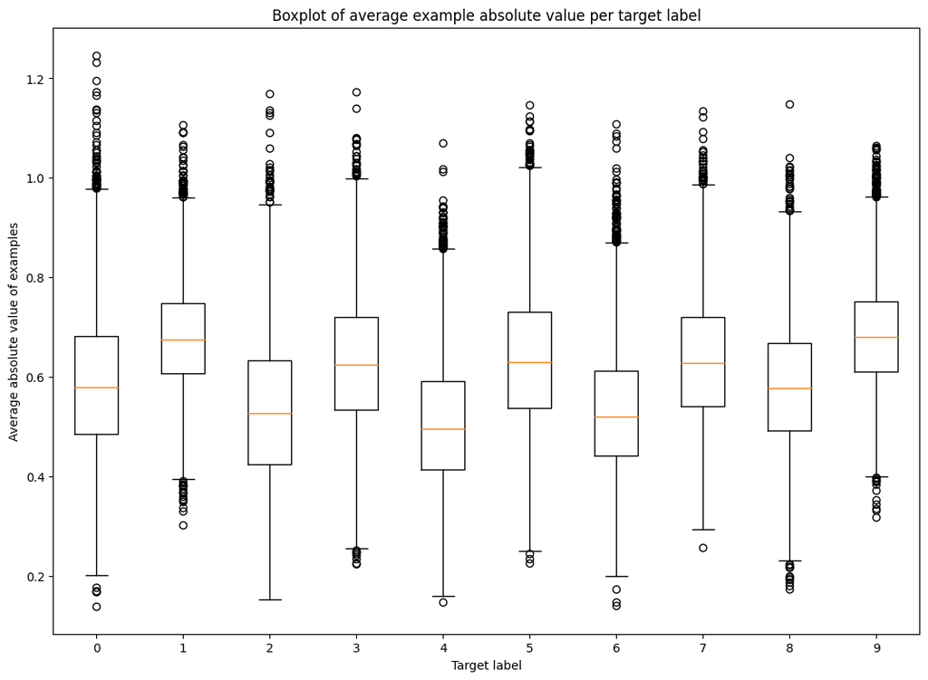

```python
# Plot the mean absolute example value per target category
data = []
for label in range(10):
  data.append([np.mean(val) for i, val in enumerate(np.absolute(train_data)) if train_label[i]==label])

fig = plt.figure(figsize =(10, 7))
ax = fig.add_axes([0, 0, 1, 1])
bp = ax.boxplot(data)
ax.set_xticklabels([x for x in range(10)])
plt.title("Boxplot of average example absolute value per target label")
plt.xlabel("Target label")
plt.ylabel("Average absolute value of examples")
plt.show()
```

```python
# CHECK IF THERE ARE MISSING VALUES IN THE TRAINING DATA
x = np.concatenate([np.array(i) for i in train_data])
np.isnan(x).sum()
```

```
0
```

No missing values!

## Data pre-processing

### Standardization

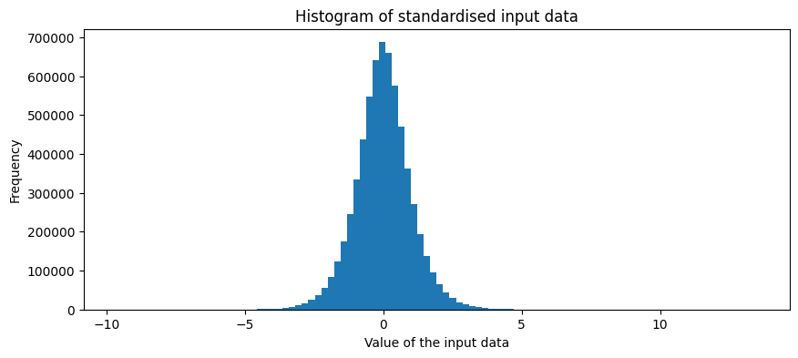

```python
# Standardize the data (mean=0, std=1)
from sklearn.preprocessing import StandardScaler

std_scaler = StandardScaler()
std_scaler.fit(train_data)

train_data_std = std_scaler.transform(train_data)
test_data_std = std_scaler.transform(test_data)

y = np.concatenate([np.array(i) for i in train_data_std])
plt.figure(figsize=(10,4))
plt.hist(y, bins=100)
plt.title("Histogram of standardised input data")
plt.xlabel("Value of the input data")
plt.ylabel("Frequency")
plt.show()
```

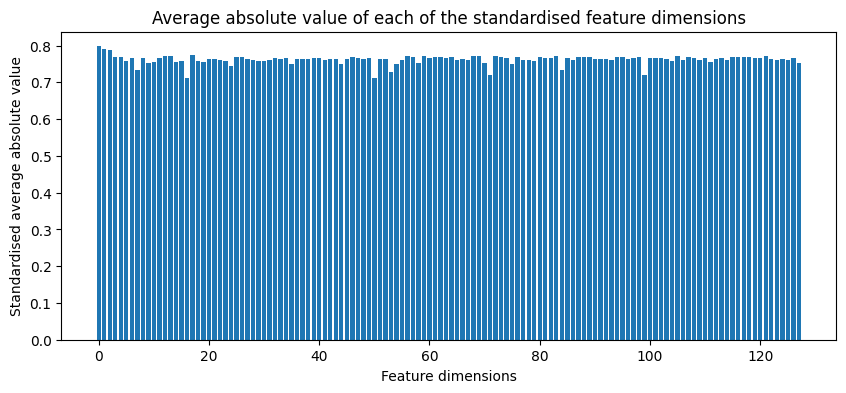

```python
# Mean absolute value of each dimension for the standardized data
means = np.mean(np.absolute(train_data_std), axis=0)
x = [i for i in range(len(means))]
y = means
plt.figure(figsize=(10,4))
plt.bar(x, y)
plt.title("Average absolute value of each of the standardised feature dimensions")
plt.xlabel("Feature dimensions")
plt.ylabel("Standardised average absolute value")
plt.show()
```

### Normalization

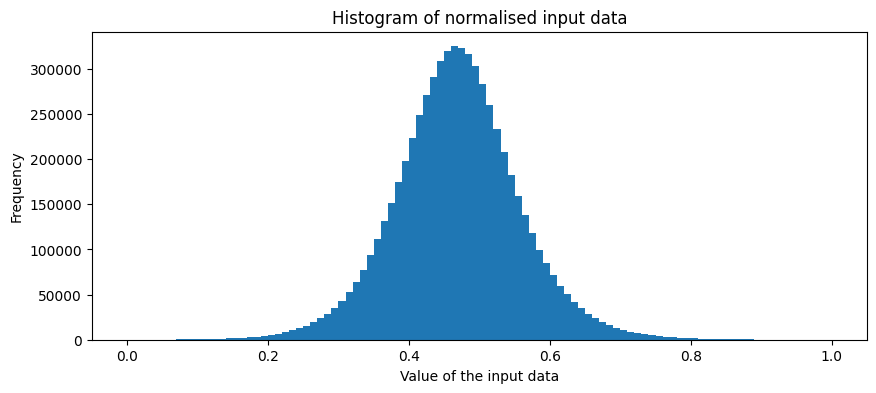

```python
# Normalize the data (transform so that each value is in the interval [0,1])
from sklearn.preprocessing import MinMaxScaler

norm_scaler = MinMaxScaler()
norm_scaler.fit(train_data)

train_data_norm = norm_scaler.transform(train_data)
test_data_norm = norm_scaler.transform(test_data)

y = np.concatenate([np.array(i) for i in train_data_norm])
plt.figure(figsize=(10,4))
plt.hist(y, bins=100)
plt.title("Histogram of normalised input data")
plt.xlabel("Value of the input data")
plt.ylabel("Frequency")
plt.show()
```

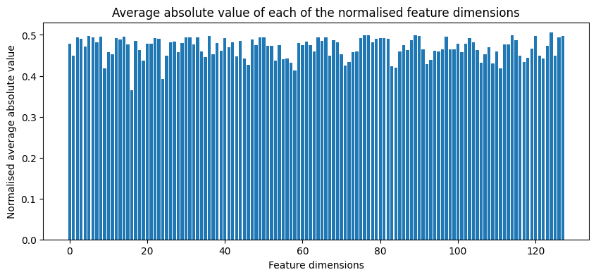

```python
# Mean absolute value of each dimension for the normalized data
means = np.mean(np.absolute(train_data_norm), axis=0)
x = [i for i in range(len(means))]
y = means
plt.figure(figsize=(10,4))
plt.bar(x, y)
plt.title("Average absolute value of each of the normalised feature dimensions")
plt.xlabel("Feature dimensions")
plt.ylabel("Normalised average absolute value")
plt.show()
```

### Principal Component Analysis (PCA)

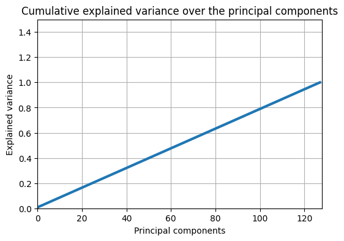

```python
# Principal component analysis for the training data
from sklearn.decomposition import PCA
pca = PCA()
pca.fit(train_data_std)
# Plot the cumulative explained variance per principle component
pca_x = pca.transform(train_data_std)
cumsum = np.cumsum(pca.explained_variance_ratio_)
plt.figure(figsize = (6,4))
plt.plot(cumsum, linewidth=3)
plt.axis([0, 128, 0, 1.5])
plt.title("Cumulative explained variance over the principal components")
plt.xlabel("Principal components")
plt.ylabel("Explained variance")
plt.grid(True)
plt.show()
```

All dimensions seem equally important, as there is a linear relation between the number of dimensions and the explained variance. Therefore, PCA will not be used in this project.

## Define activation functions

```python
### DEFINE THE ACTIVATION FUNCTIONS
class Activation(object):

    def __tanh(self, x):
        return np.tanh(x)

    def __tanh_deriv(self, a):
        # a = np.tanh(x)
        return 1.0 - a**2

    def __logistic(self, x):
        return 1.0 / (1.0 + np.exp(-x))

    def __logistic_deriv(self, a):
        # a = logistic(x)
        return  a * (1 - a )

    def __relu(self, x):
        return np.maximum(0, x)

    def __relu_deriv(self, x):
        return (x > 0) * 1

    def __leakyrelu(self, x):
        return np.where(x>=0, x, 0.01*x)

    def __leakyrelu_deriv(self, x):
        return np.where(x>=0, 1, 0.01)

    def __gelu(self, x):
        cdf = 0.5 * (1.0 + erf(x / np.sqrt(2.0)))
        return x*cdf

    def __gelu_deriv(self, x):
        cdf = 0.5 * (1.0 + erf(x / np.sqrt(2.0)))
        pdf = norm.pdf(x)
        return cdf + x*pdf

    # def __softmax(self, x):
    #     exps = np.exp(x)
    #     return exps / (np.sum(exps, axis=0)+1e-10)
    #     # exps = np.exp(x-np.max(x, axis = -1, keepdims =True))
    #     # return exps / np.sum(exps, axis = -1, keepdims = True)

    # def __softmax_deriv(self, x):
    #     # Derivative of softmax function
    #     s = self.__softmax(x)
    #     return s * (1 - s)

    def __init__(self, activation='tanh'):

        if activation == 'logistic':
            self.f = self.__logistic
            self.f_deriv = self.__logistic_deriv

        elif activation == 'tanh':
            self.f = self.__tanh
            self.f_deriv = self.__tanh_deriv

        elif activation == 'relu':
            self.f = self.__relu
            self.f_deriv = self.__relu_deriv

        elif activation == 'leakyrelu':
            self.f = self.__leakyrelu
            self.f_deriv = self.__leakyrelu_deriv

        elif activation == 'gelu':
            self.f = self.__gelu
            self.f_deriv = self.__gelu_deriv

        # elif activation == 'softmax':
        #     self.f = self.__softmax
        #     self.f_deriv = self.__softmax_deriv
```

## Define hidden layer class

```python
### DEFINE THE HIDDEN LAYER CLASS
class HiddenLayer(object):
    def __init__(self,n_in, n_out,
                 activation_last_layer='tanh', activation='tanh',
                 W=None, b=None, dropout_rate=0):
        """
        Typical hidden layer of a MLP: units are fully-connected and have
        sigmoidal activation function. Weight matrix W is of shape (n_in,n_out)
        and the bias vector b is of shape (n_out,).

        NOTE : The nonlinearity used here is tanh

        Hidden unit activation is given by: tanh(dot(input,W) + b)

        :type n_in: int
        :param n_in: dimensionality of input

        :type n_out: int
        :param n_out: number of hidden units

        :type activation: string
        :param activation: Non linearity to be applied in the hidden
                           layer
        """
        self.input=None
        self.activation=Activation(activation).f

        # activation deriv of last layer
        self.activation_deriv=None
        if activation_last_layer:
            self.activation_deriv=Activation(activation_last_layer).f_deriv

        # we randomly assign small values for the weights as the initiallization
        self.W = np.random.uniform(
                low=-np.sqrt(6. / (n_in + n_out)),
                high=np.sqrt(6. / (n_in + n_out)),
                size=(n_in, n_out)
        )

        # we set the size of bias as the size of output dimension
        self.b = np.zeros(n_out,)

        # we set he size of weight gradation as the size of weight
        self.grad_W = np.zeros(self.W.shape)
        self.grad_b = np.zeros(self.b.shape)

        # Momentum term
        self.v_W = np.zeros(self.W.shape)
        self.v_b = np.zeros(self.b.shape)


    # the forward and backward progress (in the hidden layer level) for each training epoch
    # please learn the week2 lec contents carefully to understand these codes.
    def forward(self, input, train=True):
        '''
        :type input: numpy.array
        :param input: a symbolic tensor of shape (n_in,)
        '''

        lin_output = np.dot(input, self.W) + self.b

        self.output = (
            lin_output if self.activation is None
            else self.activation(lin_output)
        )

        self.input=input

        return self.output

    def backward(self, delta, output_layer=False):

        self.grad_W = np.atleast_2d(self.input).T.dot(np.atleast_2d(delta))
        self.grad_b = delta

        if self.activation_deriv:
            delta = delta.dot(self.W.T) * self.activation_deriv(self.input)
        return delta

    def dropout(self, X):
        self.dropout_indices = np.random.choice(X.shape[0], int(X.shape[0]*self.dropout_rate), replace=False)
        return self.dropout_indices, self.dropout_rate
```

## Define Dropout Layer

```python
### DEFINE THE DROPOUT LAYER CLASS
class DropoutLayer(object):

  def __init__(self, dropout_rate=0.5):
    self.dropout_rate = dropout_rate
    self.indices = None
    self.mask = None

  def forward(self, X, train=True):
    if train:
      self.mask = np.random.uniform(size = X.shape) > self.dropout_rate
      X = X*self.mask
      X = X/(1-self.dropout_rate)
      return X
    else:
      return X

  def backward(self, delta, output_layer=False):
    delta = delta*self.mask
    return delta
```

## Define Batch Normalization Layer

```python
### DEFINE THE BATCH NORMALIZATION CLASS
class BatchNormalizationLayer(object):

  def __init__(self, n_out):

    self.beta = np.zeros(n_out,)
    self.gamma = np.ones(n_out,)

    self.grad_beta = np.zeros(self.beta.shape)
    self.grad_gamma = np.zeros(self.gamma.shape)

    self.eps = 1e-10

    self.mean = None
    self.var = None

    self.momentum=0.9

    self.running_mean = 0
    self.running_var = 0

    self.input = None
    self.x_centered = 0
    self.std = 0
    self.x_norm = 0
    self.output = None

  def forward(self, x, train=True):

    self.input = x

    if train:

      # Compute batch statistics
      batch_mean = np.mean(x, axis=0)
      batch_var = np.var(x, axis=0)

      # Normalize input data
      self.x_centered = x - batch_mean
      self.std = np.sqrt(batch_var + self.eps)
      self.x_norm = self.x_centered / self.std

      # Scale and shift normalized data
      self.output = self.gamma * self.x_norm + self.beta

      # Update running statistics
      self.running_mean = self.momentum * self.running_mean + (1 - self.momentum) * batch_mean
      self.running_var = self.momentum * self.running_var + (1 - self.momentum) * batch_var

    else:

      self.x_centered = x - self.running_mean
      self.std = np.sqrt(self.running_var + self.eps)
      self.x_norm = self.x_centered / self.std
      self.output = self.gamma * self.x_norm + self.beta

    return self.output


  def backward(self, delta):

    # Variables
    x_norm = self.x_norm
    x_centered = self.x_centered
    std = self.std
    gamma = self.gamma

    # Updating the beta and gamma gradients
    self.grad_gamma = np.sum(delta*x_norm, axis = 0)
    self.grad_beta = delta

    # Back propagating the normalization
    delta_norm = delta*gamma
    delta_centered = delta_norm / std
    delta_mean = - (delta_centered.sum(axis=0) + 2/delta.shape[0] * x_centered.sum(axis=0))
    delta_std = (delta_norm * x_centered * -(std**(-2))).sum(axis=0)
    delta_var = delta_std / 2 / std
    delta = delta_centered + (delta_mean + delta_var * 2 * x_centered) / delta.shape[0]

    return delta
```

## Define multiple layer perceptron model

```python
### DEFINE THE MLP CLASS
class MLP:
    # for initiallization, the code will create all layers automatically based on the provided parameters.
    def __init__(self, layers, activation=[None,'tanh','tanh','tanh'], dropout_rate=0, BN=False, mini_batch=False):
        """
        :param layers: A list containing the number of units in each layer.
        Should be at least two values
        :param activation: The activation function to be used. Can be
        "logistic" or "tanh"
        """
        ### initialize layers
        self.layers=[]
        self.params=[]
        self.mini_batch = mini_batch

        self.activation=activation
        for i in range(len(layers)-1):
            self.layers.append(HiddenLayer(layers[i],layers[i+1],activation[i],activation[i+1], dropout_rate=dropout_rate))
            # Initialize batch normalization layer
            if BN:
              if (i != len(layers)-2):
                self.layers.append(BatchNormalizationLayer(layers[i+1]))
            # Initialize dropout layer
            if dropout_rate != 0:
              if (i != len(layers)-2):
                self.layers.append(DropoutLayer(dropout_rate))

    # MSE Loss Function - Not used in this project
    def criterion_MSE(self,y,y_hat):
        activation_deriv=Activation(self.activation[-1]).f_deriv
        error = y-y_hat
        loss = error**2
        delta = -error*activation_deriv(y_hat)
        return loss,delta

    # Softmax function
    def softmax(self, x):
        exps = np.exp(x)
        return exps / (np.sum(exps, axis=0)+1e-10)

    # Cross-entropy loss function
    def cross_entropy_loss(self, y, y_hat):
        y_hat = self.softmax(y_hat)
        loss = - np.sum(y * np.log(y_hat+1e-10))
        error = y - y_hat
        delta = - error
        return loss, delta

    # forward progress: pass the information through the layers and out the results of final output layer
    def forward(self, input, train=True):
        for layer in self.layers:
            output=layer.forward(input, train=train)
            input=output
        return output

    # backward progress
    def backward(self, delta):
        delta=self.layers[-1].backward(delta,output_layer=True)
        for i, layer in enumerate(reversed(self.layers[:-1])):
            delta=layer.backward(delta)

    # update the network weights after backward pass
    def update(self, lr, weight_decay, momentum):
        for layer in self.layers:

            # Update the parameter of the hidden layer
            if isinstance(layer, HiddenLayer):

                # Update momentum term
                layer.v_W = momentum*layer.v_W + (1-momentum)*layer.grad_W
                layer.v_b = momentum*layer.v_b + (1-momentum)*layer.grad_b

                # Update weights with inclusion of weight decay and momentum term
                layer.W = layer.W*(1-weight_decay) - lr*layer.v_W
                layer.b = layer.b*(1-weight_decay) - lr*layer.v_b

            # Update the parameters of the batch normalisation layer
            if isinstance(layer, BatchNormalizationLayer):

                layer.gamma -= lr * layer.grad_gamma
                layer.beta -= lr * layer.grad_beta


    # define the training function
    def fit(self, X, y, learning_rate=0.1, weight_decay=0, momentum=0, batch_size=512, epochs=100):
        """
        Online learning.
        :param X: Input data or features
        :param y: Input targets
        :param learning_rate: parameters defining the speed of learning
        :param epochs: number of times the dataset is presented to the network for learning
        """

        X=np.array(X)
        y=np.array(y)
        to_return = np.zeros(epochs)

        # If-clause for mini-batch training
        if self.mini_batch:

          n_batches = X.shape[0] // batch_size

          for k in range(epochs):

              loss=np.zeros(X.shape[0])

              for num in range(n_batches):

                  X_batch = X[num*batch_size:(num+1)*batch_size]
                  y_batch = y[num*batch_size:(num+1)*batch_size]
                  loss_batch = np.zeros(X_batch.shape[0])

                  for it in range(X_batch.shape[0]):

                    # forward pass
                    y_hat = self.forward(X_batch[it])
                    # backward pass
                    loss_batch[it], delta = self.cross_entropy_loss(y_batch[it], y_hat)
                    # loss[it], delta = self.cross_entropy_loss(y[i],y_hat)
                    self.backward(delta)

                    # update
                  self.update(learning_rate, weight_decay, momentum)
                  loss[num] = np.mean(loss_batch)
              sum_loss = np.sum(loss)
              to_return[k] = sum_loss/n_batches   #np.mean(loss)
              print('epoch {} '.format(k+1),'--- loss: {}'.format(to_return[k]))

        # If-clause for no mini-batch training
        else:
          for k in range(epochs):
              loss=np.zeros(X.shape[0])
              for it in range(X.shape[0]):
                  i=np.random.randint(X.shape[0])

                  # forward pass
                  y_hat = self.forward(X[i], train=True)

                  # backward pass
                  loss[it], delta = self.cross_entropy_loss(y[i],y_hat)
                  self.backward(delta)

                  # update
                  self.update(learning_rate, weight_decay, momentum)

              to_return[k] = np.mean(loss)
              print('epoch {} '.format(k+1),'--- loss: {}'.format(to_return[k]))
        return to_return, y_hat

    # define the prediction function
    def predict(self, x, y):
        x = np.array(x)
        one_hot_output = []
        cross_entropy_losses = []
        accuracies = 0
        label_output = np.zeros(x.shape[0])

        for i in np.arange(x.shape[0]):
            result = self.forward(x[i], train=False)
            one_hot_output.append(result)

            loss, _ = self.cross_entropy_loss(y[i], result)
            cross_entropy_losses.append(loss)

            pred_number = np.argmax(result)
            label_output[i] = pred_number

            if pred_number == np.argmax(y[i]):
              accuracies += 1

        accuracy = accuracies / x.shape[0]

        return label_output, one_hot_output, cross_entropy_losses, accuracy
```

```python
# Here is our code for creating one hot vector
def one_hot_gen(data,size):
    data_one_hot = np.empty([data.shape[0],size])
    for idx, val in np.ndenumerate(data):
      y1= np.zeros(size)
      # print(y1)
      y1[val.item()] = 1
      # print(y1)
      data_one_hot[idx[0]] = y1
    return data_one_hot
```

## Train the best performing model

```
epoch 1  --- loss: 1.6618948895911285
epoch 2  --- loss: 1.4254605373619251
epoch 3  --- loss: 1.3198507889759121
epoch 4  --- loss: 1.2387335732629925
epoch 5  --- loss: 1.1686735367466095
epoch 6  --- loss: 1.1214653391592164
epoch 7  --- loss: 1.0620682590586177
epoch 8  --- loss: 1.0119498953620572
epoch 9  --- loss: 0.9593115689824454
epoch 10  --- loss: 0.9154324730359623
epoch 11  --- loss: 0.8633507505384252
epoch 12  --- loss: 0.8166598402151042
epoch 13  --- loss: 0.7768676183927516
epoch 14  --- loss: 0.741582259699907
epoch 15  --- loss: 0.6981498863208662
epoch 16  --- loss: 0.6688746319895187
epoch 17  --- loss: 0.6239978840890323
epoch 18  --- loss: 0.5945258379120132
epoch 19  --- loss: 0.5589749848449569
epoch 20  --- loss: 0.5256031997931333
epoch 21  --- loss: 0.4861778455564975
epoch 22  --- loss: 0.46359675533270145
epoch 23  --- loss: 0.4327024786687679
epoch 24  --- loss: 0.40239955618699413
epoch 25  --- loss: 0.37885361965415376
loss:0.378854
training time: 52.81658509174983 minutes
Prediction loss: 1.861453062203516
Prediction acc: 0.5371
```

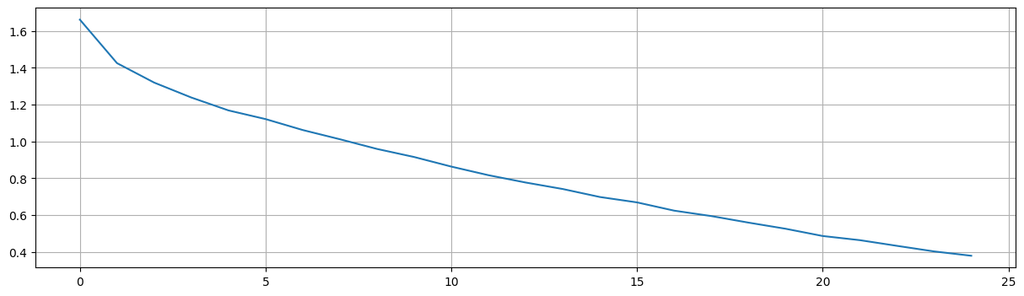

```python
# The parameters of this model have been decided on based on the results of
# the experiments of the next section
nn = MLP([128, 512, 256, 10], [None,'relu','relu','relu'], dropout_rate = 0, BN=False , mini_batch=False)
input_data = train_data
output_data = train_label
output_data_one_hot = one_hot_gen(train_label,10)

start = time.time()
loss, y_hat = nn.fit(input_data, output_data_one_hot, learning_rate=0.001, weight_decay=0, batch_size=0, momentum=0.9, epochs=25)
training_time = time.time() - start
print('loss:%f'%loss[-1])
print('training time:' , training_time/60 , 'minutes')
plt.figure(figsize=(15,4))
plt.plot(loss)
plt.grid()

start = time.time()
label, one_hot, loss, acc = nn.predict(test_data, one_hot_gen(test_label, 10))
print("Prediction loss:", np.mean(loss))
print("Prediction acc:", np.mean(acc))
testing_time = time.time() - start
```

```python
# Performance metrics
y_true = list([i[0] for i in test_label])
y_pred = [int(i) for i in list(label)]
print("Training time: {:.2f}".format(training_time), "s")
print("Testing time: {:.2f}".format(testing_time), "s")
print("Accuracy: {:.2%}".format(accuracy_score(y_true, y_pred)))
print("F1-Score: {:.2%}".format(f1_score(y_true, y_pred,average='macro')))
print(classification_report(y_true, y_pred))
```

```
Training time: 3169.00 s
Testing time: 2.77 s
Accuracy: 53.71%
F1-Score: 53.80%
              precision    recall  f1-score   support

           0       0.64      0.52      0.57      1000
           1       0.67      0.60      0.63      1000
           2       0.40      0.46      0.43      1000
           3       0.37      0.39      0.38      1000
           4       0.50      0.40      0.44      1000
           5       0.43      0.47      0.45      1000
           6       0.53      0.64      0.58      1000
           7       0.64      0.57      0.60      1000
           8       0.68      0.69      0.68      1000
           9       0.58      0.64      0.61      1000

    accuracy                           0.54     10000
   macro avg       0.54      0.54      0.54     10000
weighted avg       0.54      0.54      0.54     10000
```

## Experiments

Below, the code is provided that was used for hyperparameter analyses and ablation studies. We commented out some of the experiments to avoid longer running time of the notebook. Please uncomment the code and run the cell if you would like to run these experiments for yourself.

```python
# Here is our code for creating stratifrd K-fold for running the experiments

test_folds = [list(range(5000)),
              list(range(5000, 10000)),
              list(range(10000, 15000)),
              list(range(15000, 20000)),
              list(range(20000, 25000)),
              list(range(25000, 30000)),
              list(range(30000, 35000)),
              list(range(35000, 40000)),
              list(range(40000, 45000)),
              list(range(45000, 50000))
              ]
train_folds = [list(range(5000, 50000)),
               list(range(5000))+list(range(10000,50000)),
               list(range(10000))+list(range(15000,50000)),
               list(range(15000))+list(range(20000,50000)),
               list(range(20000))+list(range(25000,50000)),
               list(range(25000))+list(range(30000,50000)),
               list(range(30000))+list(range(35000,50000)),
               list(range(35000))+list(range(40000,50000)),
               list(range(40000))+list(range(45000,50000)),
               list(range(45000))
               ]
kfold = [(train_folds[i], test_folds[i]) for i in list(range(10))]
```

### Unpre-processed vs Standardised vs Normalised data

```python
accuracies_un = []
f1_score_un = []
training_time_un = []
testing_time_un = []

for k, (train, test) in enumerate(kfold):

  nn = MLP([128, 64, 32, 10], [None,'relu','relu','relu'], dropout_rate = 0, BN=False)

  training_data = train_data[train]
  training_label = train_label[train]
  training_label_one_hot = one_hot_gen(train_label[train],10)

  testing_data = train_data[test]
  testing_label = train_label[test]
  testing_label_one_hot = one_hot_gen(train_label[test],10)

  start = time.time()
  loss, y_hat = nn.fit(training_data, training_label_one_hot, learning_rate=0.001, weight_decay=0, momentum=0.9, epochs=10)
  training_time = time.time() - start

  start = time.time()
  label, one_hot, loss, acc = nn.predict(testing_data, testing_label_one_hot)
  testing_time = time.time() - start

  y_true = list([i[0] for i in testing_label])
  y_pred = [int(i) for i in list(label)]

  accuracy = accuracy_score(y_true, y_pred)
  f1 = f1_score(y_true, y_pred, average='macro')

  accuracies_un.append(accuracy)
  f1_score_un.append(f1)
  training_time_un.append(training_time)
  testing_time_un.append(testing_time)
```

```
epoch 1  --- loss: 1.818878665094725
epoch 2  --- loss: 1.6145805916293343
epoch 3  --- loss: 1.542687600881107
epoch 4  --- loss: 1.4898030188948819
epoch 5  --- loss: 1.4556810750644629
epoch 6  --- loss: 1.4251848329187367
epoch 7  --- loss: 1.4173160816344015
epoch 8  --- loss: 1.3935688849897871
epoch 9  --- loss: 1.366860714504633
epoch 10  --- loss: 1.3612485211088596
epoch 1  --- loss: 1.808125704406544
epoch 2  --- loss: 1.6030070404582473
epoch 3  --- loss: 1.524932309097849
epoch 4  --- loss: 1.4735633101963237
epoch 5  --- loss: 1.4368097438263496
epoch 6  --- loss: 1.412787999557203
epoch 7  --- loss: 1.3830136989620418
epoch 8  --- loss: 1.3693294385274535
epoch 9  --- loss: 1.3527287525166451
epoch 10  --- loss: 1.3296649874548536
epoch 1  --- loss: 1.7980990976243971
epoch 2  --- loss: 1.6047890515357401
epoch 3  --- loss: 1.520546604275674
epoch 4  --- loss: 1.4848746365977714
epoch 5  --- loss: 1.4381155431451382
epoch 6  --- loss: 1.4086571966524537
epoch 7  --- loss: 1.3889620235716174
epoch 8  --- loss: 1.3621677654942492
epoch 9  --- loss: 1.3372759564652932
epoch 10  --- loss: 1.3404124803102146
epoch 1  --- loss: 1.816529166863956
epoch 2  --- loss: 1.6149203951572004
epoch 3  --- loss: 1.5438465578960099
epoch 4  --- loss: 1.4854337508206534
epoch 5  --- loss: 1.4595640534993264
epoch 6  --- loss: 1.423704006146699
epoch 7  --- loss: 1.4061893455546424
epoch 8  --- loss: 1.3858832479428747
epoch 9  --- loss: 1.3655531029738754
epoch 10  --- loss: 1.3505725987722441
```

[output cut: 45 more lines]

```
epoch 6  --- loss: 1.4140995650017572
epoch 7  --- loss: 1.4006353043265034
epoch 8  --- loss: 1.36069617441401
epoch 9  --- loss: 1.3445176324505403
epoch 10  --- loss: 1.3396912479656644
epoch 1  --- loss: 1.8122289781238694
epoch 2  --- loss: 1.6069785799808953
epoch 3  --- loss: 1.5315999257434496
epoch 4  --- loss: 1.474718613445583
epoch 5  --- loss: 1.4402566268670696
epoch 6  --- loss: 1.4110628451770315
epoch 7  --- loss: 1.387146919171489
epoch 8  --- loss: 1.3548316768578712
epoch 9  --- loss: 1.3535826029294094
epoch 10  --- loss: 1.3371391185036523
```

```python
accuracies_std = []
f1_score_std = []
training_time_std = []
testing_time_std = []

for k, (train, test) in enumerate(kfold):

  nn = MLP([128, 64, 32, 10], [None,'relu','relu','relu'], dropout_rate = 0, BN=False)

  training_data = train_data_std[train]
  training_label = train_label[train]
  training_label_one_hot = one_hot_gen(train_label[train],10)

  testing_data = train_data_std[test]
  testing_label = train_label[test]
  testing_label_one_hot = one_hot_gen(train_label[test],10)

  start = time.time()
  loss, y_hat = nn.fit(training_data, training_label_one_hot, learning_rate=0.001, weight_decay=0, momentum=0.9, epochs=10)
  training_time = time.time() - start

  start = time.time()
  label, one_hot, loss, acc = nn.predict(testing_data, testing_label_one_hot)
  testing_time = time.time() - start

  y_true = list([i[0] for i in testing_label])
  y_pred = [int(i) for i in list(label)]

  accuracy = accuracy_score(y_true, y_pred)
  f1 = f1_score(y_true, y_pred,average='macro')

  accuracies_std.append(accuracy)
  f1_score_std.append(f1)
  training_time_std.append(training_time)
  testing_time_std.append(testing_time)
```

```
epoch 1  --- loss: 1.9436429332287966
epoch 2  --- loss: 1.6227948250618078
epoch 3  --- loss: 1.5059490483254738
epoch 4  --- loss: 1.4332356513622182
epoch 5  --- loss: 1.3842297253113072
epoch 6  --- loss: 1.346107812153084
epoch 7  --- loss: 1.3252538758725032
epoch 8  --- loss: 1.300666338844207
epoch 9  --- loss: 1.2774403324465458
epoch 10  --- loss: 1.2634144232912579
epoch 1  --- loss: 1.9632308364943076
epoch 2  --- loss: 1.6299411981121166
epoch 3  --- loss: 1.510643491131628
epoch 4  --- loss: 1.434651840283637
epoch 5  --- loss: 1.3849554280875775
epoch 6  --- loss: 1.334598032116659
epoch 7  --- loss: 1.3062521382635222
epoch 8  --- loss: 1.2870094963360006
epoch 9  --- loss: 1.2644305278340362
epoch 10  --- loss: 1.252997073328838
epoch 1  --- loss: 1.946102623937244
epoch 2  --- loss: 1.5942001749380967
epoch 3  --- loss: 1.484204394695929
epoch 4  --- loss: 1.40297692788335
epoch 5  --- loss: 1.367692338556397
epoch 6  --- loss: 1.3151924251525187
epoch 7  --- loss: 1.3008527931802634
epoch 8  --- loss: 1.2685296021552692
epoch 9  --- loss: 1.2555595462044327
epoch 10  --- loss: 1.231953437039272
epoch 1  --- loss: 1.9157525651145648
epoch 2  --- loss: 1.6048269849069148
epoch 3  --- loss: 1.497794406016986
epoch 4  --- loss: 1.41177047918053
epoch 5  --- loss: 1.3684580601905223
epoch 6  --- loss: 1.3188097074819674
epoch 7  --- loss: 1.2997525594623591
epoch 8  --- loss: 1.2780893892541005
epoch 9  --- loss: 1.2615059026391733
epoch 10  --- loss: 1.2529733635520957
```

[output cut: 45 more lines]

```
epoch 6  --- loss: 1.3265193641064996
epoch 7  --- loss: 1.300965404404855
epoch 8  --- loss: 1.2689042955479863
epoch 9  --- loss: 1.2529229817138334
epoch 10  --- loss: 1.2319527475119612
epoch 1  --- loss: 1.9376840753089
epoch 2  --- loss: 1.6162683695000974
epoch 3  --- loss: 1.4905314335327642
epoch 4  --- loss: 1.4196121236607102
epoch 5  --- loss: 1.3810942519652118
epoch 6  --- loss: 1.3451286332997225
epoch 7  --- loss: 1.308042194725041
epoch 8  --- loss: 1.2824431518620363
epoch 9  --- loss: 1.2663962571968583
epoch 10  --- loss: 1.2452491976634354
```

```python
accuracies_norm = []
f1_score_norm = []
training_time_norm = []
testing_time_norm = []

for k, (train, test) in enumerate(kfold):

  nn = MLP([128, 64, 32, 10], [None,'relu','relu','relu'], dropout_rate = 0, BN=False)

  training_data = train_data_norm[train]
  training_label = train_label[train]
  training_label_one_hot = one_hot_gen(train_label[train],10)

  testing_data = train_data_norm[test]
  testing_label = train_label[test]
  testing_label_one_hot = one_hot_gen(train_label[test],10)

  start = time.time()
  loss, y_hat = nn.fit(training_data, training_label_one_hot, learning_rate=0.001, weight_decay=0, momentum=0.9, epochs=10)
  training_time = time.time() - start

  start = time.time()
  label, one_hot, loss, acc = nn.predict(testing_data, testing_label_one_hot)
  testing_time = time.time() - start

  y_true = list([i[0] for i in testing_label])
  y_pred = [int(i) for i in list(label)]

  accuracy = accuracy_score(y_true, y_pred)
  f1 = f1_score(y_true, y_pred,average='macro')

  accuracies_norm.append(accuracy)
  f1_score_norm.append(f1)
  training_time_norm.append(training_time)
  testing_time_norm.append(testing_time)
```

```
epoch 1  --- loss: 2.288892917247948
epoch 2  --- loss: 2.133396799233758
epoch 3  --- loss: 1.9851190687388878
epoch 4  --- loss: 1.9263483876353773
epoch 5  --- loss: 1.8842064512419705
epoch 6  --- loss: 1.8575656421727471
epoch 7  --- loss: 1.835387941085359
epoch 8  --- loss: 1.8211798077714847
epoch 9  --- loss: 1.7999460015350037
epoch 10  --- loss: 1.8010931414932116
epoch 1  --- loss: 2.2705803282676102
epoch 2  --- loss: 2.0817823792525996
epoch 3  --- loss: 1.975334094501169
epoch 4  --- loss: 1.9089085220566582
epoch 5  --- loss: 1.871190657505496
epoch 6  --- loss: 1.842497092100162
epoch 7  --- loss: 1.827228442510752
epoch 8  --- loss: 1.8109075404829598
epoch 9  --- loss: 1.7928450494157764
epoch 10  --- loss: 1.7778505406520921
epoch 1  --- loss: 2.2897318769826898
epoch 2  --- loss: 2.130605053781417
epoch 3  --- loss: 1.9714175722837726
epoch 4  --- loss: 1.9205751879668265
epoch 5  --- loss: 1.8963121995945722
epoch 6  --- loss: 1.8520794579314486
epoch 7  --- loss: 1.829450019821597
epoch 8  --- loss: 1.8138544268708394
epoch 9  --- loss: 1.797053305686745
epoch 10  --- loss: 1.7816315545940116
epoch 1  --- loss: 2.284961414286976
epoch 2  --- loss: 2.140630601108732
epoch 3  --- loss: 2.01565965222816
epoch 4  --- loss: 1.9511654190753296
epoch 5  --- loss: 1.8997492153695463
epoch 6  --- loss: 1.8613339948871412
epoch 7  --- loss: 1.8386019652732608
epoch 8  --- loss: 1.8091410934467218
epoch 9  --- loss: 1.792934611532822
epoch 10  --- loss: 1.7810431991985953
```

[output cut: 45 more lines]

```
epoch 6  --- loss: 1.8383082831047384
epoch 7  --- loss: 1.819970829657745
epoch 8  --- loss: 1.7992217469798824
epoch 9  --- loss: 1.786954861206887
epoch 10  --- loss: 1.7674031968645023
epoch 1  --- loss: 2.28720899841589
epoch 2  --- loss: 2.1189579073147176
epoch 3  --- loss: 1.9728309944397384
epoch 4  --- loss: 1.9246323972743775
epoch 5  --- loss: 1.8848808481558808
epoch 6  --- loss: 1.8586973661438837
epoch 7  --- loss: 1.8321687574883552
epoch 8  --- loss: 1.8208299474125123
epoch 9  --- loss: 1.7967902343198483
epoch 10  --- loss: 1.7815236257735336
```

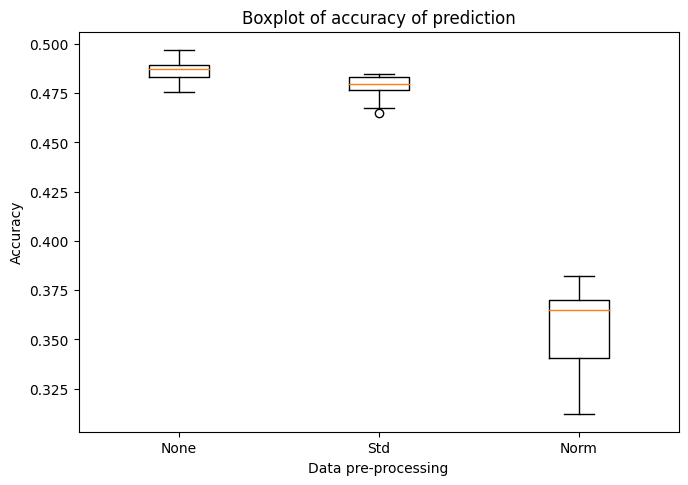

```python
data_acc = [accuracies_un, accuracies_std, accuracies_norm]
data_f1 = [f1_score_un, f1_score_std, f1_score_norm]
data_trt = [training_time_un, training_time_std, training_time_norm]
data_tet = [testing_time_un, testing_time_std, testing_time_norm]

fig = plt.figure(figsize =(6, 4))
ax = fig.add_axes([0, 0, 1, 1])
bp = ax.boxplot(data_acc)
ax.set_xticklabels(['None','Std','Norm'])
plt.title("Boxplot of accuracy of prediction")
plt.xlabel("Data pre-processing")
plt.ylabel("Accuracy")
plt.show()
```

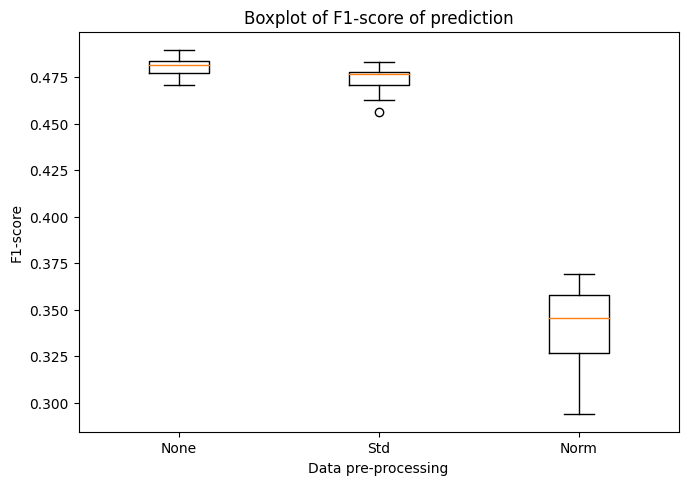

```python
fig = plt.figure(figsize =(6, 4))
ax = fig.add_axes([0, 0, 1, 1])
bp = ax.boxplot(data_f1)
ax.set_xticklabels(['None','Std','Norm'])
plt.title("Boxplot of F1-score of prediction")
plt.xlabel("Data pre-processing")
plt.ylabel("F1-score")
plt.show()
```

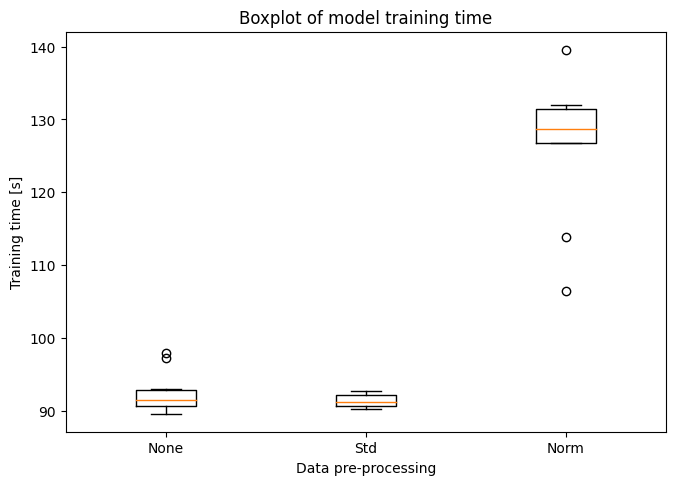

```python
fig = plt.figure(figsize =(6, 4))
ax = fig.add_axes([0, 0, 1, 1])
bp = ax.boxplot(data_trt)
ax.set_xticklabels(['None','Std','Norm'])
plt.title("Boxplot of model training time")
plt.xlabel("Data pre-processing")
plt.ylabel("Training time [s]")
plt.show()
```

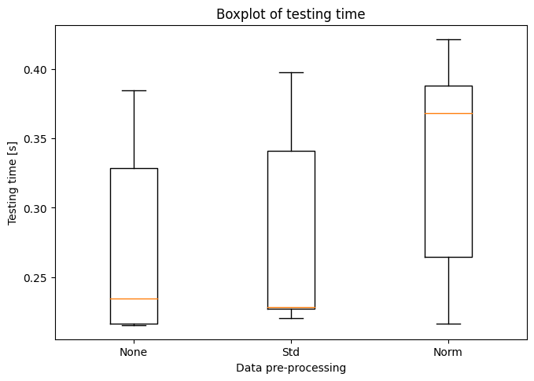

```python
fig = plt.figure(figsize =(6, 4))
ax = fig.add_axes([0, 0, 1, 1])
bp = ax.boxplot(data_tet)
ax.set_xticklabels(['None','Std','Norm'])
plt.title("Boxplot of testing time")
plt.xlabel("Data pre-processing")
plt.ylabel("Testing time [s]")
plt.show()
```

### Different activation functions

```python
activation_functions = ['relu', 'leakyrelu', 'gelu']

accuracies = []
f1_scores = []
training_times = []
testing_times = []

for af in activation_functions:

  print("Activation function:", af)

  accuracy_temp = []
  f1_score_temp = []
  training_time_temp = []
  testing_time_temp = []

  for k, (train, test) in enumerate(kfold):

    nn = MLP([128, 64, 32, 10], [None, af, af, af], dropout_rate = 0, BN=False)

    training_data = train_data[train]
    training_label = train_label[train]
    training_label_one_hot = one_hot_gen(train_label[train],10)

    testing_data = train_data[test]
    testing_label = train_label[test]
    testing_label_one_hot = one_hot_gen(train_label[test],10)

    start = time.time()
    loss, y_hat = nn.fit(training_data, training_label_one_hot, learning_rate=0.001, weight_decay=0, momentum=0.9, epochs=10)
    training_time = time.time() - start

    start = time.time()
    label, one_hot, loss, acc = nn.predict(testing_data, testing_label_one_hot)
    testing_time = time.time() - start

    y_true = list([i[0] for i in testing_label])
    y_pred = [int(i) for i in list(label)]

    accuracy = accuracy_score(y_true, y_pred)
    f1 = f1_score(y_true, y_pred, average='macro')

    accuracy_temp.append(accuracy)
    f1_score_temp.append(f1)
    training_time_temp.append(training_time)
    testing_time_temp.append(testing_time)

    if k==4:
      break

  accuracies.append(accuracy_temp)
  f1_scores.append(f1_score_temp)
  training_times.append(training_time_temp)
  testing_times.append(testing_time_temp)
```

```
Activation function: relu
epoch 1  --- loss: 1.7993410595253059
epoch 2  --- loss: 1.5891542604314277
epoch 3  --- loss: 1.4969528405586516
epoch 4  --- loss: 1.4619087136168845
epoch 5  --- loss: 1.4201048272235284
epoch 6  --- loss: 1.3958343045487
epoch 7  --- loss: 1.380209704310691
epoch 8  --- loss: 1.3481621130115042
epoch 9  --- loss: 1.3310909096016865
epoch 10  --- loss: 1.3209256575817703
epoch 1  --- loss: 1.8215627404109895
epoch 2  --- loss: 1.62756720098429
epoch 3  --- loss: 1.5456976734485819
epoch 4  --- loss: 1.4912876552062215
epoch 5  --- loss: 1.445686166890991
epoch 6  --- loss: 1.4252099548117063
epoch 7  --- loss: 1.4056977738531038
epoch 8  --- loss: 1.3840415912023976
epoch 9  --- loss: 1.3641161137671705
epoch 10  --- loss: 1.3607444796354444
epoch 1  --- loss: 1.8143365302878678
epoch 2  --- loss: 1.6074582295329773
epoch 3  --- loss: 1.5321067269269477
epoch 4  --- loss: 1.4800784609009279
epoch 5  --- loss: 1.441239801452448
epoch 6  --- loss: 1.4109329991345312
epoch 7  --- loss: 1.4017476081091516
epoch 8  --- loss: 1.3776342867561204
epoch 9  --- loss: 1.35665521204737
epoch 10  --- loss: 1.3470184672631884
epoch 1  --- loss: 1.8032093657214705
epoch 2  --- loss: 1.5821913176399924
epoch 3  --- loss: 1.5151275995146065
epoch 4  --- loss: 1.446823144353572
epoch 5  --- loss: 1.4237673756037417
epoch 6  --- loss: 1.3903003150604947
epoch 7  --- loss: 1.3686157328390074
epoch 8  --- loss: 1.3390729537349557
epoch 9  --- loss: 1.324585916584545
```

[output cut: 98 more lines]

```
epoch 6  --- loss: 1.5239013766624938
epoch 7  --- loss: 1.5319898307971702
epoch 8  --- loss: 1.5369821423913135
epoch 9  --- loss: 1.571968125017468
epoch 10  --- loss: 1.6778819948733845
epoch 1  --- loss: 1.8328843294360206
epoch 2  --- loss: 1.630945104594401
epoch 3  --- loss: 1.581167510078196
epoch 4  --- loss: 1.5428369429363442
epoch 5  --- loss: 1.5223645289503749
epoch 6  --- loss: 1.5067823806671672
epoch 7  --- loss: 1.4790508488159562
epoch 8  --- loss: 1.4750177668445397
epoch 9  --- loss: 1.476894172376812
epoch 10  --- loss: 1.4694028725453472
```

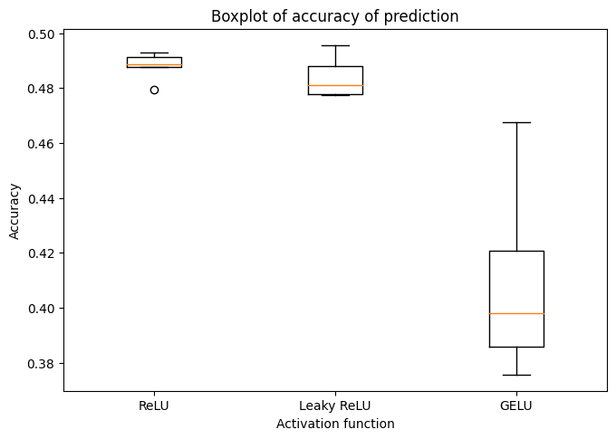

```python
fig = plt.figure(figsize =(6, 4))
ax = fig.add_axes([0, 0, 1, 1])
bp = ax.boxplot(accuracies)
ax.set_xticklabels(['ReLU','Leaky ReLU','GELU'])
plt.title("Boxplot of accuracy of prediction")
plt.xlabel("Activation function")
plt.ylabel("Accuracy")
plt.show()
```

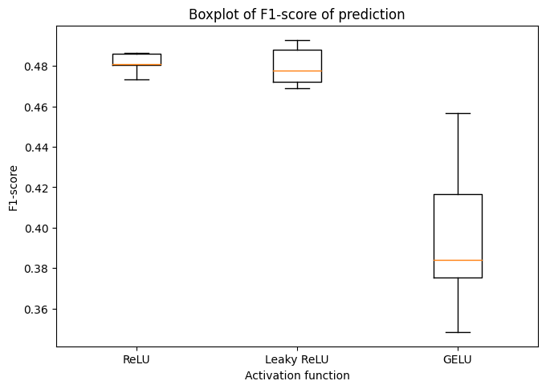

```python
fig = plt.figure(figsize =(6, 4))
ax = fig.add_axes([0, 0, 1, 1])
bp = ax.boxplot(f1_scores)
ax.set_xticklabels(['ReLU','Leaky ReLU','GELU'])
plt.title("Boxplot of F1-score of prediction")
plt.xlabel("Activation function")
plt.ylabel("F1-score")
plt.show()
```

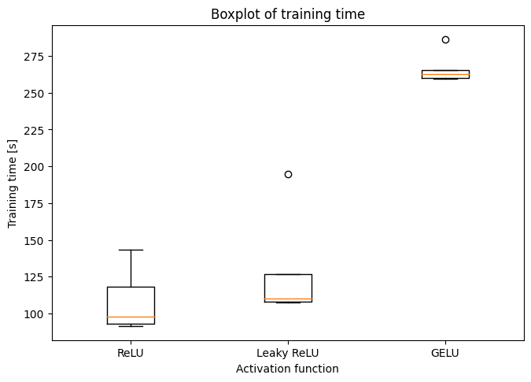

```python
fig = plt.figure(figsize =(6, 4))
ax = fig.add_axes([0, 0, 1, 1])
bp = ax.boxplot(training_times)
ax.set_xticklabels(['ReLU','Leaky ReLU','GELU'])
plt.title("Boxplot of training time")
plt.xlabel("Activation function")
plt.ylabel("Training time [s]")
plt.show()
```

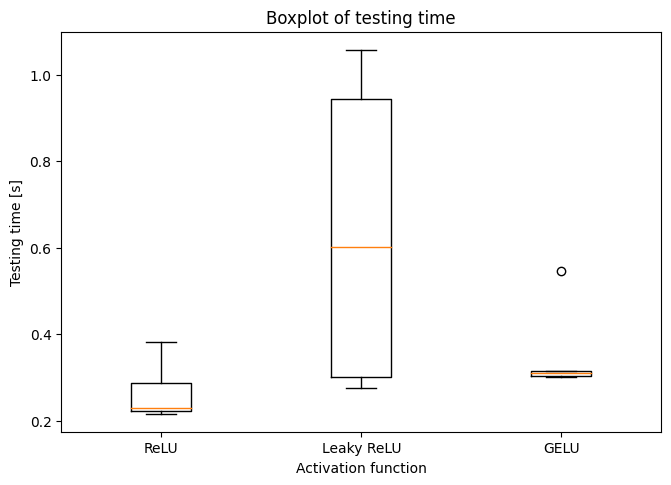

```python
fig = plt.figure(figsize =(6, 4))
ax = fig.add_axes([0, 0, 1, 1])
bp = ax.boxplot(testing_times)
ax.set_xticklabels(['ReLU','Leaky ReLU','GELU'])
plt.title("Boxplot of testing time")
plt.xlabel("Activation function")
plt.ylabel("Testing time [s]")
plt.show()
```

### Impact of model depth and width

```python
# model_architectures = [[128, 64, 32, 10],
#                        [128, 64, 64, 32, 32, 10],
#                        [128, 64, 64, 64, 64, 32, 32, 32, 32, 10],
#                        [128, 128, 64, 10],
#                        [128, 256, 128, 10],
#                        [128, 512, 256, 10]]

# accuracies = []
# f1_scores = []
# training_times = []
# testing_times = []

# for arch in model_architectures:

#   print("Model architecture:", arch)

#   accuracy_temp = []
#   f1_score_temp = []
#   training_time_temp = []
#   testing_time_temp = []

#   for k, (train, test) in enumerate(kfold):

#     nn = MLP(arch, [None]+['relu']*(len(arch)-1), dropout_rate = 0, BN=False)

#     training_data = train_data[train]
#     training_label = train_label[train]
#     training_label_one_hot = one_hot_gen(train_label[train],10)

#     testing_data = train_data[test]
#     testing_label = train_label[test]
#     testing_label_one_hot = one_hot_gen(train_label[test],10)

#     start = time.time()
#     loss, y_hat = nn.fit(training_data, training_label_one_hot, learning_rate=0.001, weight_decay=0, momentum=0.9, epochs=10)
#     training_time = time.time() - start

#     start = time.time()
#     label, one_hot, loss, acc = nn.predict(testing_data, testing_label_one_hot)
#     testing_time = time.time() - start

#     y_true = list([i[0] for i in testing_label])
#     y_pred = [int(i) for i in list(label)]

#     accuracy = accuracy_score(y_true, y_pred)
#     f1 = f1_score(y_true, y_pred, average='macro')

#     accuracy_temp.append(accuracy)
#     f1_score_temp.append(f1)
#     training_time_temp.append(training_time)
#     testing_time_temp.append(testing_time)

#     if k==4:
#       break

#   accuracies.append(accuracy_temp)
#   f1_scores.append(f1_score_temp)
#   training_times.append(training_time_temp)
#   testing_times.append(testing_time_temp)
```

```python
# fig = plt.figure(figsize =(6, 4))
# ax = fig.add_axes([0, 0, 1, 1])
# bp = ax.boxplot(accuracies)
# ax.set_xticklabels(['Baseline','Depth x2','Depth x4', 'Width x2', 'Width x4', 'Width x8'])
# plt.title("Boxplot of accuracy of prediction")
# plt.xlabel("Model architecture")
# plt.ylabel("Accuracy")
# plt.show()
```

```python
# fig = plt.figure(figsize =(6, 4))
# ax = fig.add_axes([0, 0, 1, 1])
# bp = ax.boxplot(f1_scores)
# ax.set_xticklabels(['Baseline','Depth x2','Depth x4', 'Width x2', 'Width x4', 'Width x8'])
# plt.title("Boxplot of F1-score of prediction")
# plt.xlabel("Model architecture")
# plt.ylabel("F1-score")
# plt.show()
```

```python
# fig = plt.figure(figsize =(6, 4))
# ax = fig.add_axes([0, 0, 1, 1])
# bp = ax.boxplot(training_times)
# ax.set_xticklabels(['Baseline','Depth x2','Depth x4', 'Width x2', 'Width x4', 'Width x8'])
# plt.title("Boxplot of training time")
# plt.xlabel("Model architecture")
# plt.ylabel("Training time [s]")
# plt.show()
```

```python
# fig = plt.figure(figsize =(6, 4))
# ax = fig.add_axes([0, 0, 1, 1])
# bp = ax.boxplot(testing_times)
# ax.set_xticklabels(['Baseline','Depth x2','Depth x4', 'Width x2', 'Width x4', 'Width x8'])
# plt.title("Boxplot of testing time")
# plt.xlabel("Model architecture")
# plt.ylabel("Testing time [s]")
# plt.show()
```

### Dropout vs non-dropout

```python
# different_archs = [{'model_arch':[128, 64, 32, 10], 'dropout_rate':0, 'epochs':10},
#                    {'model_arch':[128, 64, 32, 10], 'dropout_rate':0.5, 'epochs':10},
#                    {'model_arch':[128, 64, 32, 10], 'dropout_rate':0, 'epochs':50},
#                    {'model_arch':[128, 64, 32, 10], 'dropout_rate':0.5, 'epochs':50},
#                    {'model_arch':[128, 256, 128, 10], 'dropout_rate':0, 'epochs':10},
#                    {'model_arch':[128, 256, 128, 10], 'dropout_rate':0.5, 'epochs':10}]

# accuracies = []
# f1_scores = []
# training_times = []
# testing_times = []

# for dic in different_archs:

#   print(dic)

#   ma = dic['model_arch']
#   dr = dic['dropout_rate']
#   ep = dic['epochs']

#   accuracy_temp = []
#   f1_score_temp = []
#   training_time_temp = []
#   testing_time_temp = []

#   for k, (train, test) in enumerate(kfold):

#     nn = MLP(ma, [None]+['relu']*(len(ma)-1), dropout_rate = dr, BN=False)

#     training_data = train_data[train]
#     training_label = train_label[train]
#     training_label_one_hot = one_hot_gen(train_label[train],10)

#     testing_data = train_data[test]
#     testing_label = train_label[test]
#     testing_label_one_hot = one_hot_gen(train_label[test],10)

#     start = time.time()
#     loss, y_hat = nn.fit(training_data, training_label_one_hot, learning_rate=0.001, weight_decay=0, momentum=0.9, epochs=ep)
#     training_time = time.time() - start

#     start = time.time()
#     label, one_hot, loss, acc = nn.predict(testing_data, testing_label_one_hot)
#     testing_time = time.time() - start

#     y_true = list([i[0] for i in testing_label])
#     y_pred = [int(i) for i in list(label)]

#     accuracy = accuracy_score(y_true, y_pred)
#     f1 = f1_score(y_true, y_pred, average='macro')

#     accuracy_temp.append(accuracy)
#     f1_score_temp.append(f1)
#     training_time_temp.append(training_time)
#     testing_time_temp.append(testing_time)

#     if k==4:
#       break

#   accuracies.append(accuracy_temp)
#   f1_scores.append(f1_score_temp)
#   training_times.append(training_time_temp)
#   testing_times.append(testing_time_temp)
```

```python
# fig = plt.figure(figsize =(6, 4))
# ax = fig.add_axes([0, 0, 1, 1])
# bp = ax.boxplot(accuracies)
# ax.set_xticklabels(['No dropout','Dropout','No dropout','Dropout','No dropout','Dropout'])
# plt.text(x=1.25,y=0.38,s="10 epochs\n Undeep")
# plt.text(x=3.25,y=0.38,s="50 epochs\n Undeep")
# plt.text(x=5.25,y=0.38,s="10 epochs\n Deep")
# plt.title("Boxplot of accuracy of prediction")
# plt.xlabel("Neural network design")
# plt.ylabel("Accuracy")
# plt.show()
```

```python
# fig = plt.figure(figsize =(6, 4))
# ax = fig.add_axes([0, 0, 1, 1])
# bp = ax.boxplot(f1_scores)
# ax.set_xticklabels(['No dropout','Dropout','No dropout','Dropout','No dropout','Dropout'])
# plt.text(x=1.25,y=0.38,s="10 epochs\n Undeep")
# plt.text(x=3.25,y=0.38,s="50 epochs\n Undeep")
# plt.text(x=5.25,y=0.38,s="10 epochs\n Deep")
# plt.title("Boxplot of F1-score of prediction")
# plt.xlabel("Neural network design")
# plt.ylabel("F1-score")
# plt.show()
```

```python
# fig = plt.figure(figsize =(6, 4))
# ax = fig.add_axes([0, 0, 1, 1])
# bp = ax.boxplot(training_times)
# ax.set_xticklabels(['No dropout','Dropout','No dropout','Dropout','No dropout','Dropout'])
# plt.text(x=1.25,y=150,s="10 epochs\n Undeep")
# plt.text(x=3.25,y=150,s="50 epochs\n Undeep")
# plt.text(x=5.25,y=150,s="10 epochs\n Deep")
# plt.title("Boxplot of training time of model")
# plt.xlabel("Neural network design")
# plt.ylabel("Training time [s]")
# plt.show()
```

```python
# fig = plt.figure(figsize =(6, 4))
# ax = fig.add_axes([0, 0, 1, 1])
# bp = ax.boxplot(testing_times)
# ax.set_xticklabels(['No dropout','Dropout','No dropout','Dropout','No dropout','Dropout'])
# plt.text(x=1.25,y=0.45,s="10 epochs\n Undeep")
# plt.text(x=3.25,y=0.45,s="50 epochs\n Undeep")
# plt.text(x=5.25,y=0.45,s="10 epochs\n Deep")
# plt.title("Boxplot of testing time of model")
# plt.xlabel("Neural network design")
# plt.ylabel("Testing time [s]")
# plt.show()
```

### Learning rate

```python
# learning_rates = [0.0001, 0.001, 0.01, 0.1]

# accuracies = []
# f1_scores = []
# training_times = []
# testing_times = []

# for lr in learning_rates:

#   print("Learning rate:", lr)

#   accuracy_temp = []
#   f1_score_temp = []
#   training_time_temp = []
#   testing_time_temp = []

#   for k, (train, test) in enumerate(kfold):

#     nn = MLP([128, 64, 32, 10], [None,'relu','relu','relu'], dropout_rate = 0, BN=False)

#     training_data = train_data[train]
#     training_label = train_label[train]
#     training_label_one_hot = one_hot_gen(train_label[train],10)

#     testing_data = train_data[test]
#     testing_label = train_label[test]
#     testing_label_one_hot = one_hot_gen(train_label[test],10)

#     start = time.time()
#     loss, y_hat = nn.fit(training_data, training_label_one_hot, learning_rate=lr, weight_decay=0, momentum=0.9, epochs=10)
#     training_time = time.time() - start

#     start = time.time()
#     label, one_hot, loss, acc = nn.predict(testing_data, testing_label_one_hot)
#     testing_time = time.time() - start

#     y_true = list([i[0] for i in testing_label])
#     y_pred = [int(i) for i in list(label)]

#     accuracy = accuracy_score(y_true, y_pred)
#     f1 = f1_score(y_true, y_pred, average='macro')

#     accuracy_temp.append(accuracy)
#     f1_score_temp.append(f1)
#     training_time_temp.append(training_time)
#     testing_time_temp.append(testing_time)

#   accuracies.append(accuracy_temp)
#   f1_scores.append(f1_score_temp)
#   training_times.append(training_time_temp)
#   testing_times.append(testing_time_temp)
```

```python
# fig = plt.figure(figsize =(6, 4))
# ax = fig.add_axes([0, 0, 1, 1])
# bp = ax.boxplot(accuracies)
# ax.set_xticklabels(['0.0001','0.001','0.01','0.1'])
# plt.title("Boxplot of accuracy of prediction")
# plt.xlabel("Learning rate value")
# plt.ylabel("Accuracy")
# plt.show()
```

```python
# fig = plt.figure(figsize =(6, 4))
# ax = fig.add_axes([0, 0, 1, 1])
# bp = ax.boxplot(f1_scores)
# ax.set_xticklabels(['0.0001','0.001','0.01','0.1'])
# plt.title("Boxplot of F1-score of prediction")
# plt.xlabel("Learning rate value")
# plt.ylabel("F1-score")
# plt.show()
```

```python
# fig = plt.figure(figsize =(6, 4))
# ax = fig.add_axes([0, 0, 1, 1])
# bp = ax.boxplot(training_times)
# ax.set_xticklabels(['0.0001','0.001','0.01','0.1'])
# plt.title("Boxplot of training time")
# plt.xlabel("Learning rate value")
# plt.ylabel("Training time [s]")
# plt.show()
```

```python
# fig = plt.figure(figsize =(6, 4))
# ax = fig.add_axes([0, 0, 1, 1])
# bp = ax.boxplot(testing_times)
# ax.set_xticklabels(['0.0001','0.001','0.01','0.1'])
# plt.title("Boxplot of testing time")
# plt.xlabel("Learning rate value")
# plt.ylabel("Testing time [s]")
# plt.show()
```

### Momentum

```python
# momentums = [0, 0.9, 0.95, 0.99]

# accuracies = []
# f1_scores = []
# training_times = []
# testing_times = []

# for mom in momentums:

#   print("Momentum:", mom)

#   accuracy_temp = []
#   f1_score_temp = []
#   training_time_temp = []
#   testing_time_temp = []

#   for k, (train, test) in enumerate(kfold):

#     nn = MLP([128, 64, 32, 10], [None,'relu','relu','relu'], dropout_rate = 0, BN=False)

#     training_data = train_data[train]
#     training_label = train_label[train]
#     training_label_one_hot = one_hot_gen(train_label[train],10)

#     testing_data = train_data[test]
#     testing_label = train_label[test]
#     testing_label_one_hot = one_hot_gen(train_label[test],10)

#     start = time.time()
#     loss, y_hat = nn.fit(training_data, training_label_one_hot, learning_rate=0.001, weight_decay=0, momentum=mom, epochs=10)
#     training_time = time.time() - start

#     start = time.time()
#     label, one_hot, loss, acc = nn.predict(testing_data, testing_label_one_hot)
#     testing_time = time.time() - start

#     y_true = list([i[0] for i in testing_label])
#     y_pred = [int(i) for i in list(label)]

#     accuracy = accuracy_score(y_true, y_pred)
#     f1 = f1_score(y_true, y_pred, average='macro')

#     accuracy_temp.append(accuracy)
#     f1_score_temp.append(f1)
#     training_time_temp.append(training_time)
#     testing_time_temp.append(testing_time)

#   accuracies.append(accuracy_temp)
#   f1_scores.append(f1_score_temp)
#   training_times.append(training_time_temp)
#   testing_times.append(testing_time_temp)
```

```python
# fig = plt.figure(figsize =(6, 4))
# ax = fig.add_axes([0, 0, 1, 1])
# bp = ax.boxplot(accuracies)
# ax.set_xticklabels(['0','0.9','0.95','0.99'])
# plt.title("Boxplot of accuracy of prediction")
# plt.xlabel("Momentum value")
# plt.ylabel("Accuracy")
# plt.show()
```

```python
# fig = plt.figure(figsize =(6, 4))
# ax = fig.add_axes([0, 0, 1, 1])
# bp = ax.boxplot(f1_scores)
# ax.set_xticklabels(['0','0.9','0.95','0.99'])
# plt.title("Boxplot of F1-score of prediction")
# plt.xlabel("Momentum value")
# plt.ylabel("F1-score")
# plt.show()
```

```python
# fig = plt.figure(figsize =(6, 4))
# ax = fig.add_axes([0, 0, 1, 1])
# bp = ax.boxplot(training_times)
# ax.set_xticklabels(['0','0.9','0.95','0.99'])
# plt.title("Boxplot of training time")
# plt.xlabel("Momentum value")
# plt.ylabel("Training time [s]")
# plt.show()
```

```python
# fig = plt.figure(figsize =(6, 4))
# ax = fig.add_axes([0, 0, 1, 1])
# bp = ax.boxplot(testing_times)
# ax.set_xticklabels(['0','0.9','0.95','0.99'])
# plt.title("Boxplot of testing time")
# plt.xlabel("Momentum value")
# plt.ylabel("Testing time [s]")
# plt.show()
```

### Weight decay

```python
# weight_decays = [0, 0.01, 0.02]

# accuracies = []
# f1_scores = []
# training_times = []
# testing_times = []

# for wd in weight_decays:

#   print("Weight decay:", wd)

#   accuracy_temp = []
#   f1_score_temp = []
#   training_time_temp = []
#   testing_time_temp = []

#   for k, (train, test) in enumerate(kfold):

#     nn = MLP([128, 64, 32, 10], [None,'relu','relu','relu'], dropout_rate = 0, BN=False)

#     training_data = train_data[train]
#     training_label = train_label[train]
#     training_label_one_hot = one_hot_gen(train_label[train],10)

#     testing_data = train_data[test]
#     testing_label = train_label[test]
#     testing_label_one_hot = one_hot_gen(train_label[test],10)

#     start = time.time()
#     loss, y_hat = nn.fit(training_data, training_label_one_hot, learning_rate=0.001, weight_decay=wd, momentum=0.9, epochs=10)
#     training_time = time.time() - start

#     start = time.time()
#     label, one_hot, loss, acc = nn.predict(testing_data, testing_label_one_hot)
#     testing_time = time.time() - start

#     y_true = list([i[0] for i in testing_label])
#     y_pred = [int(i) for i in list(label)]

#     accuracy = accuracy_score(y_true, y_pred)
#     f1 = f1_score(y_true, y_pred, average='macro')

#     accuracy_temp.append(accuracy)
#     f1_score_temp.append(f1)
#     training_time_temp.append(training_time)
#     testing_time_temp.append(testing_time)

#   accuracies.append(accuracy_temp)
#   f1_scores.append(f1_score_temp)
#   training_times.append(training_time_temp)
#   testing_times.append(testing_time_temp)
```

```python
# fig = plt.figure(figsize =(6, 4))
# ax = fig.add_axes([0, 0, 1, 1])
# bp = ax.boxplot(accuracies)
# ax.set_xticklabels(['0','0.01','0.02'])
# plt.title("Boxplot of accuracy of prediction")
# plt.xlabel("Weight decay value")
# plt.ylabel("Accuracy")
# plt.show()
```

```python
# fig = plt.figure(figsize =(6, 4))
# ax = fig.add_axes([0, 0, 1, 1])
# bp = ax.boxplot(f1_scores)
# ax.set_xticklabels(['0','0.01','0.02'])
# plt.title("Boxplot of F1-score of prediction")
# plt.xlabel("Weight decay value")
# plt.ylabel("F1-score")
# plt.show()
```

```python
# fig = plt.figure(figsize =(6, 4))
# ax = fig.add_axes([0, 0, 1, 1])
# bp = ax.boxplot(training_times)
# ax.set_xticklabels(['0','0.01','0.02'])
# plt.title("Boxplot of training time")
# plt.xlabel("Weight decay value")
# plt.ylabel("Training time [s]")
# plt.show()
```

```python
# fig = plt.figure(figsize =(6, 4))
# ax = fig.add_axes([0, 0, 1, 1])
# bp = ax.boxplot(testing_times)
# ax.set_xticklabels(['0','0.01','0.02'])
# plt.title("Boxplot of testing time")
# plt.xlabel("Weight decay value")
# plt.ylabel("Testing time [s]")
# plt.show()
```

### Mini-batch training

```python
# mini_batch = True
# different_archs = [{'batch_size':32, 'epochs':10, 'mini_batch':True},
#                    {'batch_size':64, 'epochs':15, 'mini_batch':True},
#                    {'batch_size':256, 'epochs':25, 'mini_batch':True},
#                    {'batch_size':1024, 'epochs':50, 'mini_batch':True},
#                    {'batch_size':0, 'epochs':10, 'mini_batch':False}]


# accuracies = []
# f1_scores = []
# training_times = []
# testing_times = []

# for dic in different_archs:
#   print(dic)

#   mbs = dic['batch_size']
#   mini_batch = dic['mini_batch']
#   epoch = dic['epochs']

#   accuracy_temp = []
#   f1_score_temp = []
#   training_time_temp = []
#   testing_time_temp = []

#   for k, (train, test) in enumerate(kfold):

#     nn = MLP([128, 64, 32, 10], [None,'relu','relu','relu'], dropout_rate = 0, BN=False , mini_batch=mini_batch)

#     training_data = train_data[train]
#     training_label = train_label[train]
#     training_label_one_hot = one_hot_gen(train_label[train],10)

#     testing_data = train_data[test]
#     testing_label = train_label[test]
#     testing_label_one_hot = one_hot_gen(train_label[test],10)

#     start = time.time()
#     loss, y_hat = nn.fit(training_data, training_label_one_hot, learning_rate=0.001, weight_decay=0, momentum=0.9, batch_size=mbs, epochs=epoch)
#     training_time = time.time() - start

#     start = time.time()
#     label, one_hot, loss, acc = nn.predict(testing_data, testing_label_one_hot)
#     testing_time = time.time() - start

#     y_true = list([i[0] for i in testing_label])
#     y_pred = [int(i) for i in list(label)]

#     accuracy = accuracy_score(y_true, y_pred)
#     f1 = f1_score(y_true, y_pred, average='macro')

#     accuracy_temp.append(accuracy)
#     f1_score_temp.append(f1)
#     training_time_temp.append(training_time)
#     testing_time_temp.append(testing_time)

#     if k==3:
#       break

#   accuracies.append(accuracy_temp)
#   f1_scores.append(f1_score_temp)
#   training_times.append(training_time_temp)
#   testing_times.append(testing_time_temp)
```

```python
# fig = plt.figure(figsize =(6, 4))
# ax = fig.add_axes([0, 0, 1, 1])
# bp = ax.boxplot(accuracies)
# ax.set_xticklabels(['32,10','64,15','256,25','1024,50','no MB,10'])
# plt.title("Boxplot of accuracy of prediction")
# plt.xlabel("mini batch size, number of epochs")
# plt.ylabel("Accuracy")
# plt.show()
```

```python
# fig = plt.figure(figsize =(6, 4))
# ax = fig.add_axes([0, 0, 1, 1])
# bp = ax.boxplot(f1_scores)
# ax.set_xticklabels(['32,10','64,15','256,25','1024,50','no MB,10'])
# plt.title("Boxplot of F1-score of prediction")
# plt.xlabel("mini batch size, number of epochs")
# plt.ylabel("F1-score")
# plt.show()
```

```python
# fig = plt.figure(figsize =(6, 4))
# ax = fig.add_axes([0, 0, 1, 1])
# bp = ax.boxplot(training_times)
# ax.set_xticklabels(['32,10','64,15','256,25','1024,50','no MB,10'])
# plt.title("Boxplot of training time")
# plt.xlabel("mini batch size, number of epochs")
# plt.ylabel("Training time [s]")
# plt.show()
```

```python
# fig = plt.figure(figsize =(6, 4))
# ax = fig.add_axes([0, 0, 1, 1])
# bp = ax.boxplot(testing_times)
# ax.set_xticklabels(['32,10','64,15','256,25','1024,50','no MB,10'])
# plt.title("Boxplot of testing time")
# plt.xlabel("mini batch size, number of epochs")
# plt.ylabel("Testing time [s]")
# plt.show()
```

### Batch normalisation

```python
# batch_norms = [{"bn":True, 'lr':0.001},
#                {"bn":False, 'lr':0.001},
#                {"bn":True, 'lr':0.01},
#                {"bn":False, 'lr':0.01}]

# accuracies = []
# f1_scores = []
# training_times = []
# testing_times = []

# for dic in batch_norms:

#   print("Batch normalisation:", dic)
#   bn = dic["bn"]
#   lr = dic["lr"]

#   accuracy_temp = []
#   f1_score_temp = []
#   training_time_temp = []
#   testing_time_temp = []

#   for k, (train, test) in enumerate(kfold):

#     nn = MLP([128, 64, 32, 10], [None,'relu','relu','relu'], dropout_rate = 0, BN=bn)

#     training_data = train_data[train]
#     training_label = train_label[train]
#     training_label_one_hot = one_hot_gen(train_label[train],10)

#     testing_data = train_data[test]
#     testing_label = train_label[test]
#     testing_label_one_hot = one_hot_gen(train_label[test],10)

#     start = time.time()
#     loss, y_hat = nn.fit(training_data, training_label_one_hot, learning_rate=lr, weight_decay=0, momentum=0.9, epochs=10)
#     training_time = time.time() - start

#     start = time.time()
#     label, one_hot, loss, acc = nn.predict(testing_data, testing_label_one_hot)
#     testing_time = time.time() - start

#     y_true = list([i[0] for i in testing_label])
#     y_pred = [int(i) for i in list(label)]

#     accuracy = accuracy_score(y_true, y_pred)
#     f1 = f1_score(y_true, y_pred, average='macro')

#     accuracy_temp.append(accuracy)
#     f1_score_temp.append(f1)
#     training_time_temp.append(training_time)
#     testing_time_temp.append(testing_time)

#     if k==3:
#       break

#   accuracies.append(accuracy_temp)
#   f1_scores.append(f1_score_temp)
#   training_times.append(training_time_temp)
#   testing_times.append(testing_time_temp)
```

```
Batch normalisation: {'bn': True, 'lr': 0.001}
epoch 1  --- loss: 1.8510887667735385
epoch 2  --- loss: 1.6315286005443697
epoch 3  --- loss: 1.5697894515911448
epoch 4  --- loss: 1.518612079484941
epoch 5  --- loss: 1.4844817862885011
epoch 6  --- loss: 1.4615896960761676
epoch 7  --- loss: 1.4513819746865086
epoch 8  --- loss: 1.434959438826055
epoch 9  --- loss: 1.4158543204089067
epoch 10  --- loss: 1.4055787103923512
epoch 1  --- loss: 1.8531949856696994
epoch 2  --- loss: 1.6595070820863944
epoch 3  --- loss: 1.586249759373062
epoch 4  --- loss: 1.5382547074410955
epoch 5  --- loss: 1.4992453480154615
epoch 6  --- loss: 1.47521269525698
epoch 7  --- loss: 1.455931217811527
epoch 8  --- loss: 1.4432551878245063
epoch 9  --- loss: 1.413836451656605
epoch 10  --- loss: 1.4024343039324083
epoch 1  --- loss: 1.8322049483392142
epoch 2  --- loss: 1.6418237947049175
epoch 3  --- loss: 1.5588670125181694
epoch 4  --- loss: 1.5238705644660293
epoch 5  --- loss: 1.4942063703874318
epoch 6  --- loss: 1.4708917794675087
epoch 7  --- loss: 1.4572242386478518
epoch 8  --- loss: 1.4380906584396893
epoch 9  --- loss: 1.4256879999505894
epoch 10  --- loss: 1.407010457358233
epoch 1  --- loss: 1.8428535447265957
epoch 2  --- loss: 1.6306837077144951
epoch 3  --- loss: 1.5561688354480323
epoch 4  --- loss: 1.5189493033432298
epoch 5  --- loss: 1.4843698074402518
epoch 6  --- loss: 1.4431378230184544
epoch 7  --- loss: 1.4347896177501098
epoch 8  --- loss: 1.4156826667260507
epoch 9  --- loss: 1.4019375636726024
```

[output cut: 109 more lines]

```
epoch 6  --- loss: 1.727241910059402
epoch 7  --- loss: 1.7268896135817502
epoch 8  --- loss: 1.7303796991472595
epoch 9  --- loss: 1.7109424364179713
epoch 10  --- loss: 1.6990107192330197
epoch 1  --- loss: 1.8730400917688332
epoch 2  --- loss: 1.7896394259904518
epoch 3  --- loss: 1.7678597299601342
epoch 4  --- loss: 1.7399174348294613
epoch 5  --- loss: 1.7614815229081915
epoch 6  --- loss: 1.7419403322664666
epoch 7  --- loss: 1.7285628205042514
epoch 8  --- loss: 1.7278741978318088
epoch 9  --- loss: 1.7154512472059762
epoch 10  --- loss: 1.7126198452363768
```

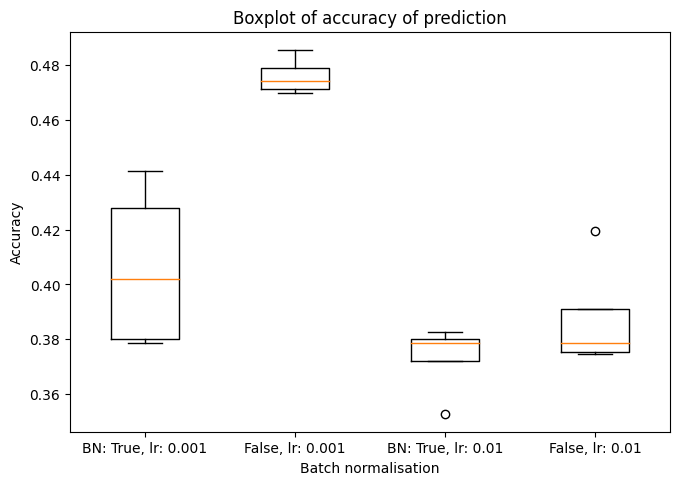

```python
# fig = plt.figure(figsize =(6, 4))
# ax = fig.add_axes([0, 0, 1, 1])
# bp = ax.boxplot(accuracies)
# ax.set_xticklabels(['BN: True, lr: 0.001','False, lr: 0.001', 'BN: True, lr: 0.01','False, lr: 0.01'])
# plt.title("Boxplot of accuracy of prediction")
# plt.xlabel("Batch normalisation")
# plt.ylabel("Accuracy")
# plt.show()
```

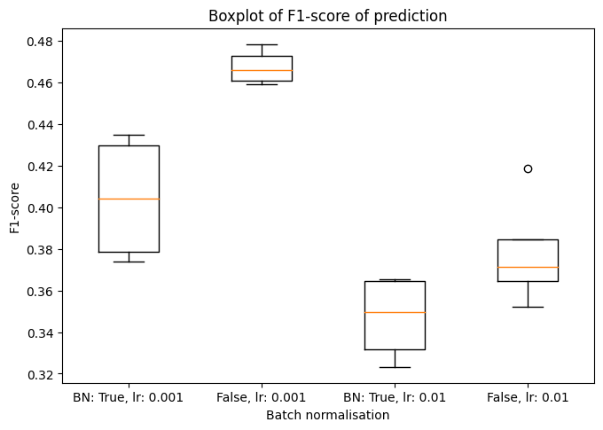

```python
# fig = plt.figure(figsize =(6, 4))
# ax = fig.add_axes([0, 0, 1, 1])
# bp = ax.boxplot(f1_scores)
# ax.set_xticklabels(['BN: True, lr: 0.001','False, lr: 0.001', 'BN: True, lr: 0.01','False, lr: 0.01'])
# plt.title("Boxplot of F1-score of prediction")
# plt.xlabel("Batch normalisation")
# plt.ylabel("F1-score")
# plt.show()
```

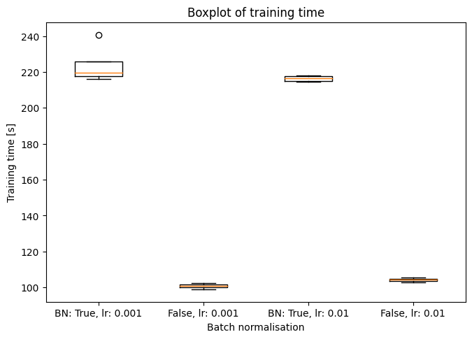

```python
# fig = plt.figure(figsize =(6, 4))
# ax = fig.add_axes([0, 0, 1, 1])
# bp = ax.boxplot(training_times)
# ax.set_xticklabels(['BN: True, lr: 0.001','False, lr: 0.001', 'BN: True, lr: 0.01','False, lr: 0.01'])
# plt.title("Boxplot of training time")
# plt.xlabel("Batch normalisation")
# plt.ylabel("Training time [s]")
# plt.show()
```

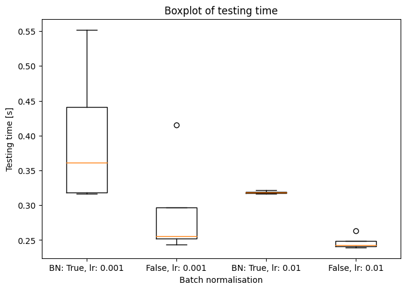

```python
# fig = plt.figure(figsize =(6, 4))
# ax = fig.add_axes([0, 0, 1, 1])
# bp = ax.boxplot(testing_times)
# ax.set_xticklabels(['BN: True, lr: 0.001','False, lr: 0.001', 'BN: True, lr: 0.01','False, lr: 0.01'])
# plt.title("Boxplot of testing time")
# plt.xlabel("Batch normalisation")
# plt.ylabel("Testing time [s]")
# plt.show()
```

## Visuals

```python
def relu(x):
    return np.maximum(0, x)
def relu_deriv(x):
    return (x > 0) * 1
def leakyrelu(x):
    return np.where(x>=0, x, 0.01*x)
def leakyrelu_deriv(x):
    return np.where(x>=0, 1, 0.01)
def gelu(x):
    cdf = 0.5 * (1.0 + erf(x / np.sqrt(2.0)))
    return x * cdf
def gelu_deriv(x):
    cdf = 0.5 * (1.0 + erf(x / np.sqrt(2.0)))
    pdf = norm.pdf(x)
    y = cdf + x*pdf
    return y
```

```python
x = np.array(np.linspace(-3,3,100))
```

```
<function matplotlib.pyplot.show(close=None, block=None)>
```

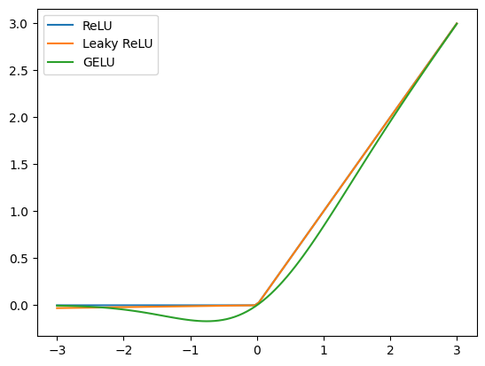

```python
plt.plot(x, relu(x))
plt.plot(x, leakyrelu(x))
plt.plot(x, gelu(x))
plt.legend(['ReLU','Leaky ReLU','GELU'])
plt.show
```

```
<function matplotlib.pyplot.show(close=None, block=None)>
```

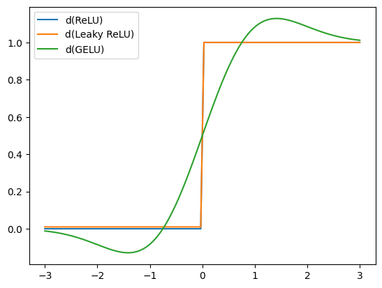

```python
plt.plot(x, relu_deriv(x))
plt.plot(x, leakyrelu_deriv(x))
plt.plot(x, gelu_deriv(x))
plt.legend(['d(ReLU)','d(Leaky ReLU)','d(GELU)'])
plt.show
```